# 02-pandas-for-manipulating-gff3 slides

## Start Jupyter notebook on Nova on demand.

You can start Jupyter notebook on Nova on demand. This will allow you to run Jupyter notebook on the server and access it from your local machine.

1. Go to the [Nova OnDemand](https://nova-ondemand.its.iastate.edu/) and login
2. Under the "Interactive Apps" tab, click on "Jupyter Notebook", request desired resources and click "Launch"
3. Wait for the job to start and click on the "Connect to Jupyter" button

## Getting Started

For this short exercise, we will be using the `pandas` library in Python to manipulate a GFF3 file. GFF3 is a file format used for storing genomic features in a plain text format. It is a tab-delimited file that describes the features of a genome assembly. Each line in the file represents a feature, such as a gene, exon, or CDS. These features can be nested, eg: CDS, and exons are within the mRNA feature, mRNA is within the gene feature.

The file is divided into nine columns (usually referred as attributes column), will contain feature specific information and is not standardized. The first eight columns are mandatory and are as follows:

1. `seqid`: chromosome or scaffold the feature is located.
2. `source`: Source of the feature, eg: a database or tool that generated the feature.
3. `type`: feature type, eg: `gene`, `mRNA`, `CDS`, `exon` etc.
4. `start`: genomic start position of the feature.
5. `end`: genomic end position of the feature.
6. `score`: Feature score, can be a floating-point number, missing is represented by "`.`".
7. `strand`: strand of the feature, can be + or -, missing is represented by "`.`".
8. `phase`: usually for `CDS` feature, and can be `0`, `1`, or `2`. missing is represented by "`.`".
9. `attributes`: a semicolon-separated list of tag-value pairs, where the tag and value are separated by `=`. The tag-value pairs are feature specific.

## Importing the required libraries

We will be using the `pandas` library to read and manipulate the GFF3 file. We will also use the `os` library to check if the file exists. Later for plotting, we will also use the `seaborn` library. And one specific function from `matplotlib` library to save the plots.

```python
import pandas as pd
import os
import seaborn as sns
import matplotlib.pyplot as plt
```

## Download the GFF3 files

We will use maize annotation file for B73 downloaded from MaizeGDB for this tutorial. The file is located [here](https://download.maizegdb.org/Zm-B73-REFERENCE-NAM-5.0/) but it has been pre-downloaded to the working directory.

The file name is `Zm-B73-REFERENCE-NAM-5.0_Zm00001eb.1.gff3.gz`

These are unix commands and you can simply prefix `!` to run them on Jupyter notebook.

```python
!wget https://download.maizegdb.org/Zm-B73-REFERENCE-NAM-5.0/Zm-B73-REFERENCE-NAM-5.0_Zm00001eb.1.gff3.gz
!gunzip Zm-B73-REFERENCE-NAM-5.0_Zm00001eb.1.gff3.gz
```

```
--2025-03-21 10:05:34--  https://download.maizegdb.org/Zm-B73-REFERENCE-NAM-5.0/Zm-B73-REFERENCE-NAM-5.0_Zm00001eb.1.gff3.gz
Resolving download.maizegdb.org (download.maizegdb.org)... 172.67.74.80, 104.26.10.112, 104.26.11.112, ...
Connecting to download.maizegdb.org (download.maizegdb.org)|172.67.74.80|:443... connected.
HTTP request sent, awaiting response... 200 OK
Length: 12251264 (12M) [application/x-gzip]
Saving to: ‘Zm-B73-REFERENCE-NAM-5.0_Zm00001eb.1.gff3.gz’

Zm-B73-REFERENCE-NA 100%[===================>]  11.68M  --.-KB/s    in 0.1s

2025-03-21 10:05:34 (87.9 MB/s) - ‘Zm-B73-REFERENCE-NAM-5.0_Zm00001eb.1.gff3.gz’ saved [12251264/12251264]
```

**Note**: If we rerun this cell, we might get an error since the file already exists in the directory. Be sure to either delete or skip this cell when rerunning.

Let's look at our data before we try to process it with python. We can use another unix command `head` here, but we still need to use the `!` prefix to tell Jupyter that this is a unix command.

```python
!head Zm-B73-REFERENCE-NAM-5.0_Zm00001eb.1.gff3
```

```
##gff-version 3
# generated on Thu Jul  2 15:00:44 2020 by /sonas-hs/ware/hpc/home/olson/src/warelab/gramene-ensembl/scripts/dump-scripts/sharon_gff_dump_by_logicname_nam.pl
# for species Maize b73
# genebuild 2019-cshl
chr1	assembly	chromosome	1	308452471	.	.	.	ID=1;Name=chromosome:Zm-B73-REFERENCE-NAM-5.0:1:1:308452471:1
chr1	NAM	gene	34617	40204	.	+	.	ID=Zm00001eb000010;biotype=protein_coding;logic_name=cshl_gene
chr1	NAM	mRNA	34617	40204	.	+	.	ID=Zm00001eb000010_T001;Parent=Zm00001eb000010;biotype=protein_coding;transcript_id=Zm00001eb000010_T001;canonical_transcript=1
chr1	NAM	five_prime_UTR	34617	34721	.	+	.	Parent=Zm00001eb000010_T001
chr1	NAM	exon	34617	35318	.	+	.	Parent=Zm00001eb000010_T001;Name=Zm00001eb000010_T001.exon.1;ensembl_end_phase=0;ensembl_phase=0;exon_id=Zm00001eb000010_T001.exon.1;rank=1
chr1	NAM	exon	36037	36174	.	+	.	Parent=Zm00001eb000010_T001;Name=Zm00001eb000010_T001.exon.2;ensembl_end_phase=0;ensembl_phase=0;exon_id=Zm00001eb000010_T001.exon.2;rank=2
```

## Reading the GFF3 file

We will use the `pd.read_csv` function to read the GFF3 file. Since the file is tab-delimited, we will use the `sep` argument to specify the delimiter. We will also use the `comment` argument to skip the header lines in the file.

```python
gff3_file = "Zm-B73-REFERENCE-NAM-5.0_Zm00001eb.1.gff3"
columns = ['seqid', 'source', 'type', 'start', 'end', 'score', 'strand', 'phase', 'attributes']
gff3_df = pd.read_csv(gff3_file, sep='\t', comment='#', header=None, names=columns)
```

With `os` library, we can check if the file exists before reading it. This will prevent an error if `gff3_file` is NULL.

```python
if os.path.exists(gff3_file):
    gff3_df = pd.read_csv(gff3_file, sep='\t', comment='#', header=None, names=columns)
else:
    print(f"{gff3_file} does not exist")
```

## 1. Explore the data

Let's take a look at the first few rows of the dataframe to understand the structure of the data.

```python
gff3_df.head()
```

|  | seqid | source | type | start | end | score | strand | phase | attributes |
| --- | --- | --- | --- | --- | --- | --- | --- | --- | --- |
| 0 | chr1 | assembly | chromosome | 1 | 308452471 | . | . | . | ID=1;Name=chromosome:Zm-B73-REFERENCE-NAM-5.0:... |
| 1 | chr1 | NAM | gene | 34617 | 40204 | . | + | . | ID=Zm00001eb000010;biotype=protein_coding;logi... |
| 2 | chr1 | NAM | mRNA | 34617 | 40204 | . | + | . | ID=Zm00001eb000010_T001;Parent=Zm00001eb000010... |
| 3 | chr1 | NAM | five_prime_UTR | 34617 | 34721 | . | + | . | Parent=Zm00001eb000010_T001 |
| 4 | chr1 | NAM | exon | 34617 | 35318 | . | + | . | Parent=Zm00001eb000010_T001;Name=Zm00001eb0000... |

and the last few rows

```python
gff3_df.tail()
```

|  | seqid | source | type | start | end | score | strand | phase | attributes |
| --- | --- | --- | --- | --- | --- | --- | --- | --- | --- |
| 1143798 | scaf_695 | NAM | mRNA | 2336 | 4226 | . | - | . | ID=Zm00001eb443030_T001;Parent=Zm00001eb443030... |
| 1143799 | scaf_695 | NAM | five_prime_UTR | 4218 | 4226 | . | - | . | Parent=Zm00001eb443030_T001 |
| 1143800 | scaf_695 | NAM | exon | 2336 | 4226 | . | - | . | Parent=Zm00001eb443030_T001;Name=Zm00001eb4430... |
| 1143801 | scaf_695 | NAM | CDS | 2898 | 4217 | . | - | 0 | ID=Zm00001eb443030_P001;Parent=Zm00001eb443030... |
| 1143802 | scaf_695 | NAM | three_prime_UTR | 2336 | 2897 | . | - | . | Parent=Zm00001eb443030_T001 |

To examine the columns and the type of object they are assigned to, we can use the `.info()` method.

```python
gff3_df.info()
```

```
<class 'pandas.core.frame.DataFrame'>
RangeIndex: 1143803 entries, 0 to 1143802
Data columns (total 9 columns):
 #   Column      Non-Null Count    Dtype
---  ------      --------------    -----
 0   seqid       1143803 non-null  object
 1   source      1143803 non-null  object
 2   type        1143803 non-null  object
 3   start       1143803 non-null  int64
 4   end         1143803 non-null  int64
 5   score       1143803 non-null  object
 6   strand      1143803 non-null  object
 7   phase       1143803 non-null  object
 8   attributes  1143803 non-null  object
dtypes: int64(2), object(7)
memory usage: 78.5+ MB
```

Let's see the unique values in the `type` column. These are the features in the GFF3 file (*e.g.*, gene, exon, etc).

```python
gff3_df['type'].unique()
```

```
array(['chromosome', 'gene', 'mRNA', 'five_prime_UTR', 'exon', 'CDS',
       'three_prime_UTR', 'scaffold'], dtype=object)
```

We can also see what the unique values in the `seqid` column are. Often these are chromosomes, but some include scaffolds (which we may or may not want).

```python
gff3_df['seqid'].unique()
```

```
array(['chr1', 'chr2', 'chr3', 'chr4', 'chr5', 'chr6', 'chr7', 'chr8',
       'chr9', 'chr10', 'scaf_22', 'scaf_23', 'scaf_30', 'scaf_32',
       'scaf_33', 'scaf_34', 'scaf_36', 'scaf_37', 'scaf_45', 'scaf_48',
       'scaf_49', 'scaf_54', 'scaf_56', 'scaf_61', 'scaf_66', 'scaf_67',
       'scaf_72', 'scaf_77', 'scaf_82', 'scaf_87', 'scaf_88', 'scaf_94',
       'scaf_100', 'scaf_103', 'scaf_106', 'scaf_107', 'scaf_110',
       'scaf_113', 'scaf_114', 'scaf_126', 'scaf_136', 'scaf_138',
       'scaf_139', 'scaf_143', 'scaf_146', 'scaf_153', 'scaf_155',
       'scaf_158', 'scaf_160', 'scaf_161', 'scaf_173', 'scaf_174',
       'scaf_178', 'scaf_179', 'scaf_181', 'scaf_183', 'scaf_186',
       'scaf_187', 'scaf_190', 'scaf_191', 'scaf_194', 'scaf_196',
       'scaf_198', 'scaf_200', 'scaf_203', 'scaf_209', 'scaf_210',
       'scaf_212', 'scaf_214', 'scaf_219', 'scaf_221', 'scaf_222',
       'scaf_223', 'scaf_224', 'scaf_228', 'scaf_229', 'scaf_231',
       'scaf_232', 'scaf_235', 'scaf_237', 'scaf_241', 'scaf_243',
       'scaf_246', 'scaf_250', 'scaf_253', 'scaf_258', 'scaf_259',
       'scaf_264', 'scaf_273', 'scaf_274', 'scaf_275', 'scaf_277',
       'scaf_278', 'scaf_279', 'scaf_281', 'scaf_282', 'scaf_288',
       'scaf_298', 'scaf_300', 'scaf_301', 'scaf_304', 'scaf_307',
       'scaf_309', 'scaf_311', 'scaf_313', 'scaf_316', 'scaf_317',
       'scaf_328', 'scaf_332', 'scaf_339', 'scaf_345', 'scaf_348',
       'scaf_350', 'scaf_355', 'scaf_357', 'scaf_359', 'scaf_360',
       'scaf_362', 'scaf_370', 'scaf_372', 'scaf_375', 'scaf_380',
       'scaf_381', 'scaf_382', 'scaf_383', 'scaf_386', 'scaf_388',
       'scaf_398', 'scaf_399', 'scaf_409', 'scaf_410', 'scaf_412',
       'scaf_420', 'scaf_435', 'scaf_443', 'scaf_444', 'scaf_445',
       'scaf_446', 'scaf_461', 'scaf_463', 'scaf_465', 'scaf_469',
       'scaf_475', 'scaf_487', 'scaf_489', 'scaf_490', 'scaf_494',
       'scaf_498', 'scaf_507', 'scaf_512', 'scaf_514', 'scaf_516',
       'scaf_518', 'scaf_519', 'scaf_521', 'scaf_524', 'scaf_527',
       'scaf_532', 'scaf_538', 'scaf_539', 'scaf_542', 'scaf_545',
       'scaf_554', 'scaf_556', 'scaf_562', 'scaf_568', 'scaf_576',
       'scaf_579', 'scaf_582', 'scaf_585', 'scaf_587', 'scaf_592',
       'scaf_604', 'scaf_605', 'scaf_612', 'scaf_621', 'scaf_623',
       'scaf_625', 'scaf_640', 'scaf_644', 'scaf_651', 'scaf_656',
       'scaf_659', 'scaf_664', 'scaf_666', 'scaf_670', 'scaf_674',
       'scaf_675', 'scaf_692', 'scaf_695'], dtype=object)
```

## 2. Filtering the data

We are often interested chromosome features only, so we will want to remove those on the scaffolds. We can filter the dataframe to only include `seqid` column that have a match to `chr`.

```python
filter = gff3_df['seqid'].str.contains('chr')
chr_gff3_df = gff3_df[filter]
```

Check the output

```python
chr_gff3_df.head()
```

|  | seqid | source | type | start | end | score | strand | phase | attributes |
| --- | --- | --- | --- | --- | --- | --- | --- | --- | --- |
| 0 | chr1 | assembly | chromosome | 1 | 308452471 | . | . | . | ID=1;Name=chromosome:Zm-B73-REFERENCE-NAM-5.0:... |
| 1 | chr1 | NAM | gene | 34617 | 40204 | . | + | . | ID=Zm00001eb000010;biotype=protein_coding;logi... |
| 2 | chr1 | NAM | mRNA | 34617 | 40204 | . | + | . | ID=Zm00001eb000010_T001;Parent=Zm00001eb000010... |
| 3 | chr1 | NAM | five_prime_UTR | 34617 | 34721 | . | + | . | Parent=Zm00001eb000010_T001 |
| 4 | chr1 | NAM | exon | 34617 | 35318 | . | + | . | Parent=Zm00001eb000010_T001;Name=Zm00001eb0000... |

```python
chr_gff3_df.tail()
```

|  | seqid | source | type | start | end | score | strand | phase | attributes |
| --- | --- | --- | --- | --- | --- | --- | --- | --- | --- |
| 1138113 | chr10 | NAM | exon | 152286718 | 152287382 | . | - | . | Parent=Zm00001eb434590_T001;Name=Zm00001eb4345... |
| 1138114 | chr10 | NAM | CDS | 152285016 | 152286200 | . | - | 0 | ID=Zm00001eb434590_P001;Parent=Zm00001eb434590... |
| 1138115 | chr10 | NAM | CDS | 152286281 | 152286588 | . | - | 2 | ID=Zm00001eb434590_P001;Parent=Zm00001eb434590... |
| 1138116 | chr10 | NAM | CDS | 152286718 | 152287096 | . | - | 0 | ID=Zm00001eb434590_P001;Parent=Zm00001eb434590... |
| 1138117 | chr10 | NAM | three_prime_UTR | 152284763 | 152285015 | . | - | . | Parent=Zm00001eb434590_T001 |

How did this code work? First, let's look in filter

```python
filter.head()
```

```
0    True
1    True
2    True
3    True
4    True
Name: seqid, dtype: bool
```

That only told us which indices in column `seqid` contain the string 'chr', so we needed another step to only keep those indices where the boolean test returned the value `True`.

The output is correct, but we haven't used `str.contains` before. Why didn't we just use `filter = gff3_df['seqid'] == 'chr'`? (Remember that each `seqid` field is not just 'chr' but 'chr1', 'chr2', etc.)

We can use this for other filtering. Other common filters include filtering by feature type. For example, to filter only the `gene` features, we can use the following code:

```python
filter = chr_gff3_df['type'] == 'gene'
gene_df = chr_gff3_df[filter]
gene_df.head()
```

|  | seqid | source | type | start | end | score | strand | phase | attributes |
| --- | --- | --- | --- | --- | --- | --- | --- | --- | --- |
| 1 | chr1 | NAM | gene | 34617 | 40204 | . | + | . | ID=Zm00001eb000010;biotype=protein_coding;logi... |
| 23 | chr1 | NAM | gene | 41214 | 46762 | . | - | . | ID=Zm00001eb000020;biotype=protein_coding;logi... |
| 106 | chr1 | NAM | gene | 108554 | 114382 | . | - | . | ID=Zm00001eb000050;biotype=protein_coding;logi... |
| 123 | chr1 | NAM | gene | 188559 | 189581 | . | - | . | ID=Zm00001eb000060;biotype=protein_coding;logi... |
| 131 | chr1 | NAM | gene | 190192 | 198832 | . | - | . | ID=Zm00001eb000070;biotype=protein_coding;logi... |

Similar filtering can be done for the `mRNA`, `CDS`, `exon` features as well, or we could filter by strand, or by location on chromosome, etc.

## 3. Format conversion

A common task in bioinformatics is format conversion. We frequently need convert files from one format to another. The genomic coordinates in GFF3 files are 1-based, but other formats, such as [BED file format](https://useast.ensembl.org/info/website/upload/bed.html), have 0-based coordinates.

[figure not shown]

source: [biostars.org](https://www.biostars.org/p/84686/)

We will extract only `mRNA` features from the GFF3 file and convert the coordinates to 0-based and save it as a bed file.

```python
# first we extract only mRNA features
filter = chr_gff3_df['type'] == 'mRNA'
mRNA_df = chr_gff3_df[filter]
mRNA_df
```

|  | seqid | source | type | start | end | score | strand | phase | attributes |
| --- | --- | --- | --- | --- | --- | --- | --- | --- | --- |
| 2 | chr1 | NAM | mRNA | 34617 | 40204 | . | + | . | ID=Zm00001eb000010_T001;Parent=Zm00001eb000010... |
| 24 | chr1 | NAM | mRNA | 41263 | 46050 | . | - | . | ID=Zm00001eb000020_T002;Parent=Zm00001eb000020... |
| 43 | chr1 | NAM | mRNA | 41214 | 43902 | . | - | . | ID=Zm00001eb000020_T004;Parent=Zm00001eb000020... |
| 62 | chr1 | NAM | mRNA | 41314 | 46039 | . | - | . | ID=Zm00001eb000020_T003;Parent=Zm00001eb000020... |
| 85 | chr1 | NAM | mRNA | 41214 | 46762 | . | - | . | ID=Zm00001eb000020_T001;Parent=Zm00001eb000020... |
| ... | ... | ... | ... | ... | ... | ... | ... | ... | ... |
| 1138073 | chr10 | NAM | mRNA | 152010430 | 152012584 | . | - | . | ID=Zm00001eb434550_T001;Parent=Zm00001eb434550... |
| 1138079 | chr10 | NAM | mRNA | 152012893 | 152015823 | . | - | . | ID=Zm00001eb434560_T001;Parent=Zm00001eb434560... |
| 1138095 | chr10 | NAM | mRNA | 152200925 | 152201511 | . | + | . | ID=Zm00001eb434570_T001;Parent=Zm00001eb434570... |
| 1138101 | chr10 | NAM | mRNA | 152280251 | 152282615 | . | + | . | ID=Zm00001eb434580_T001;Parent=Zm00001eb434580... |
| 1138109 | chr10 | NAM | mRNA | 152284763 | 152287382 | . | - | . | ID=Zm00001eb434590_T001;Parent=Zm00001eb434590... |

71791 rows × 9 columns

In addition to the difference in indexing, bed files have a slightly different column order. All bed files typically need are three columns (*i.e.*, chromosome, feature start, and feature end). The other columns are optional, but useful. Here we will retain and reorder the first three required columns (chromosome, start, end), and also keep a few others that may be useful (`attributes`, `score`, and `strand`).

```python
mRNA_df = mRNA_df[['seqid', 'start', 'end', 'attributes', 'score', 'strand']]
mRNA_df.head()
```

|  | seqid | start | end | attributes | score | strand |
| --- | --- | --- | --- | --- | --- | --- |
| 2 | chr1 | 34617 | 40204 | ID=Zm00001eb000010_T001;Parent=Zm00001eb000010... | . | + |
| 24 | chr1 | 41263 | 46050 | ID=Zm00001eb000020_T002;Parent=Zm00001eb000020... | . | - |
| 43 | chr1 | 41214 | 43902 | ID=Zm00001eb000020_T004;Parent=Zm00001eb000020... | . | - |
| 62 | chr1 | 41314 | 46039 | ID=Zm00001eb000020_T003;Parent=Zm00001eb000020... | . | - |
| 85 | chr1 | 41214 | 46762 | ID=Zm00001eb000020_T001;Parent=Zm00001eb000020... | . | - |

We also might want to clean up the `attributes` column. Here, we only need the first attribute (ID of the mRNA feature, or transcript name). We will extract this information and add it as a new column in the dataframe. (Also, to avoid a common Pandas error, we have to make sure `mRNA_df` is a copy of the data and not a temporary view of it -- use `.copy()` when Pandas tells you `SettingWithCopyWarning: A value is trying to be set on a copy of a slice...`)

```python
mRNA_df = mRNA_df.copy()
mRNA_df['mRNA_id'] = mRNA_df['attributes'].str.split(';', expand=True)[0].str.split('=', expand=True)[1]
mRNA_df.head()
```

|  | seqid | start | end | attributes | score | strand | mRNA_id |
| --- | --- | --- | --- | --- | --- | --- | --- |
| 2 | chr1 | 34617 | 40204 | ID=Zm00001eb000010_T001;Parent=Zm00001eb000010... | . | + | Zm00001eb000010_T001 |
| 24 | chr1 | 41263 | 46050 | ID=Zm00001eb000020_T002;Parent=Zm00001eb000020... | . | - | Zm00001eb000020_T002 |
| 43 | chr1 | 41214 | 43902 | ID=Zm00001eb000020_T004;Parent=Zm00001eb000020... | . | - | Zm00001eb000020_T004 |
| 62 | chr1 | 41314 | 46039 | ID=Zm00001eb000020_T003;Parent=Zm00001eb000020... | . | - | Zm00001eb000020_T003 |
| 85 | chr1 | 41214 | 46762 | ID=Zm00001eb000020_T001;Parent=Zm00001eb000020... | . | - | Zm00001eb000020_T001 |

Great! Now we have a nice name for the mRNA, but we still have the `attributes` column and our name is at the end (when bed format specifies the name column as column 4). So, we have to rearrange (and get rid of the unnecessary `attributes` while we are at it.

```python
mRNA_df = mRNA_df[['seqid', 'start', 'end', 'mRNA_id', 'score', 'strand']]
mRNA_df.head()
```

|  | seqid | start | end | mRNA_id | score | strand |
| --- | --- | --- | --- | --- | --- | --- |
| 2 | chr1 | 34617 | 40204 | Zm00001eb000010_T001 | . | + |
| 24 | chr1 | 41263 | 46050 | Zm00001eb000020_T002 | . | - |
| 43 | chr1 | 41214 | 43902 | Zm00001eb000020_T004 | . | - |
| 62 | chr1 | 41314 | 46039 | Zm00001eb000020_T003 | . | - |
| 85 | chr1 | 41214 | 46762 | Zm00001eb000020_T001 | . | - |

Now we will convert the start position to 0-based by subtracting 1 from the start position. Why don't we subtract 1 from both the start and the end? (Hint: 0-based indexing is end *exclusive*).

```python
mRNA_df['start'] = mRNA_df['start'] - 1
mRNA_df.head()
```

|  | seqid | start | end | mRNA_id | score | strand |
| --- | --- | --- | --- | --- | --- | --- |
| 2 | chr1 | 34616 | 40204 | Zm00001eb000010_T001 | . | + |
| 24 | chr1 | 41262 | 46050 | Zm00001eb000020_T002 | . | - |
| 43 | chr1 | 41213 | 43902 | Zm00001eb000020_T004 | . | - |
| 62 | chr1 | 41313 | 46039 | Zm00001eb000020_T003 | . | - |
| 85 | chr1 | 41213 | 46762 | Zm00001eb000020_T001 | . | - |

Now that we have completed our transformations, we can save the dataframe as a bed file.

```python
mRNA_df.to_csv('B73v5_mRNA.bed', sep='\t', index=False, header=False)
```

Congratulations! You have successfully converted a GFF3 file to a BED file!

## 4. Summary Statistics

Another common task is to calculate summary statistics of various features in your GFF3 file. We can calculate the length of each feature by subtracting the start position from the end position and adding 1 (since it is 1-based -- if we were using the bed, we would not have to add 1).

```python
chr_gff3_df = chr_gff3_df.copy()
chr_gff3_df['feature_length'] = chr_gff3_df['end'] - chr_gff3_df['start'] + 1
chr_gff3_df.head()
```

|  | seqid | source | type | start | end | score | strand | phase | attributes | feature_length |
| --- | --- | --- | --- | --- | --- | --- | --- | --- | --- | --- |
| 0 | chr1 | assembly | chromosome | 1 | 308452471 | . | . | . | ID=1;Name=chromosome:Zm-B73-REFERENCE-NAM-5.0:... | 308452471 |
| 1 | chr1 | NAM | gene | 34617 | 40204 | . | + | . | ID=Zm00001eb000010;biotype=protein_coding;logi... | 5588 |
| 2 | chr1 | NAM | mRNA | 34617 | 40204 | . | + | . | ID=Zm00001eb000010_T001;Parent=Zm00001eb000010... | 5588 |
| 3 | chr1 | NAM | five_prime_UTR | 34617 | 34721 | . | + | . | Parent=Zm00001eb000010_T001 | 105 |
| 4 | chr1 | NAM | exon | 34617 | 35318 | . | + | . | Parent=Zm00001eb000010_T001;Name=Zm00001eb0000... | 702 |

Great! We have all these feature lengths, but we might only be interested in genes. We can see the total length of chromosome 1 here: 308,452,471. Maybe we want to know how much of that is genic. Let's add that up.

```python
chr_gff3_df[
    (chr_gff3_df['type'] == 'gene') &
    (chr_gff3_df['seqid'] == 'chr1')
]['feature_length'].sum()
```

```
np.int64(27147372)
```

Using the `groupby` method, we can calculate various summary statistics for each feature type on a chromosome by chromosome basis.

```python
chr_gff3_df.groupby(['seqid', 'type'])['feature_length'].agg(['count', 'sum', 'mean', 'median', 'min', 'max', 'std']).tail(7)
```

| seqid | type | count | sum | mean | median | min | max | std |
| --- | --- | --- | --- | --- | --- | --- | --- | --- |
| chr9 | CDS | 31101 | 6720102 | 2.160735e+02 | 125.0 | 1 | 4310 | 297.466918 |
|  | chromosome | 1 | 163004744 | 1.630047e+08 | 163004744.0 | 163004744 | 163004744 | NaN |
|  | exon | 34839 | 10047095 | 2.883864e+02 | 151.0 | 2 | 5072 | 372.663974 |
|  | five_prime_UTR | 7035 | 1400562 | 1.990849e+02 | 150.0 | 1 | 2973 | 188.569368 |
|  | gene | 2988 | 12875616 | 4.309108e+03 | 2623.5 | 219 | 87408 | 5833.988606 |
|  | mRNA | 5447 | 29122198 | 5.346466e+03 | 3613.0 | 219 | 87408 | 6257.689830 |
|  | three_prime_UTR | 6189 | 1926431 | 3.112669e+02 | 274.0 | 1 | 3152 | 249.061336 |

I chose to display the tail here so we could see chromosome 9. But, some of the values are in scientific notation, which we might not prefer. Let's change that.

```python
pd.options.display.float_format = '{:,.2f}'.format
```

```python
chr_gff3_df.groupby(['seqid', 'type'])['feature_length'].agg(['count', 'sum', 'mean', 'median', 'min', 'max', 'std']).tail(7)
```

| seqid | type | count | sum | mean | median | min | max | std |
| --- | --- | --- | --- | --- | --- | --- | --- | --- |
| chr9 | CDS | 31101 | 6720102 | 216.07 | 125.00 | 1 | 4310 | 297.47 |
|  | chromosome | 1 | 163004744 | 163,004,744.00 | 163,004,744.00 | 163004744 | 163004744 | NaN |
|  | exon | 34839 | 10047095 | 288.39 | 151.00 | 2 | 5072 | 372.66 |
|  | five_prime_UTR | 7035 | 1400562 | 199.08 | 150.00 | 1 | 2973 | 188.57 |
|  | gene | 2988 | 12875616 | 4,309.11 | 2,623.50 | 219 | 87408 | 5,833.99 |
|  | mRNA | 5447 | 29122198 | 5,346.47 | 3,613.00 | 219 | 87408 | 6,257.69 |
|  | three_prime_UTR | 6189 | 1926431 | 311.27 | 274.00 | 1 | 3152 | 249.06 |

```python
stats = chr_gff3_df.groupby(['seqid', 'type'])['feature_length'].agg(['count', 'sum', 'mean', 'median', 'min', 'max', 'std'])
stats.to_csv('summary_stats.csv')
!head summary_stats.csv
```

```
seqid,type,count,sum,mean,median,min,max,std
chr1,CDS,61506,13519782,219.81240854550776,123.0,1,5002,304.1946391149942
chr1,chromosome,1,308452471,308452471.0,308452471.0,308452471,308452471,
chr1,exon,68813,20446606,297.1328964003895,150.0,2,5981,388.40826544638554
chr1,five_prime_UTR,14313,2913334,203.544609795291,149.0,1,2510,207.58325687771386
chr1,gene,5892,27147372,4607.4969450101835,2779.0,219,398383,8265.511697958327
chr1,mRNA,10967,60459027,5512.813622686241,3633.0,219,398213,7747.849302570511
chr1,three_prime_UTR,12482,4013490,321.542220797949,283.0,1,4201,270.54154491650644
chr10,CDS,26860,5900430,219.6734921816828,120.0,1,6487,315.17952823891073
chr10,chromosome,1,152435371,152435371.0,152435371.0,152435371,152435371,
```

There are other ways to get stats out of the data, which you can explore on your own. An example using `.describe()`, which we learned last time, to get stats for the gene feature only:

```python
filter = chr_gff3_df['type'] == 'gene'
gene_df = chr_gff3_df[filter]
gene_df['feature_length'].describe()
```

```
count    39,035.00
mean      4,511.69
std       8,883.02
min         213.00
25%       1,240.00
50%       2,716.00
75%       5,060.00
max     751,401.00
Name: feature_length, dtype: float64
```

## 5. Visualizations

Generating count plots is a great way to visualize the distribution of features in your GFF3 file. We can use the `seaborn` library to generate count plots.

Seaborn is a Python data visualization library built on top of Matplotlib. It provides a high-level interface for creating aesthetically pleasing and informative statistical graphics. Designed for ease of use, Seaborn integrates seamlessly with Pandas, making it a powerful tool for exploratory data analysis and visualization.

We will go over Seaborn more in the next lecture, but if you want more information you can find it at https://seaborn.pydata.org/

First we will set a few plot parameters to make it look nice, then we will make a barplot of the number of each feature in the gff3 file.

```python
plt.rcParams['figure.dpi'] = 200
plt.rcParams['figure.figsize'] = 10,4
plt.rcParams.update({'font.size': 8})
```

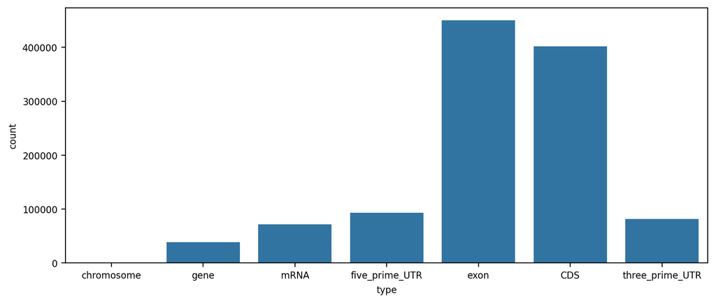

```python
sns.countplot(data=chr_gff3_df, x='type');
```

That worked well. Notice we didn't have to do any counting ourselves -- countplot took care of it for us. We also might want to view only one type of feature but divide it by chromosome. For `gene` features, we could do:

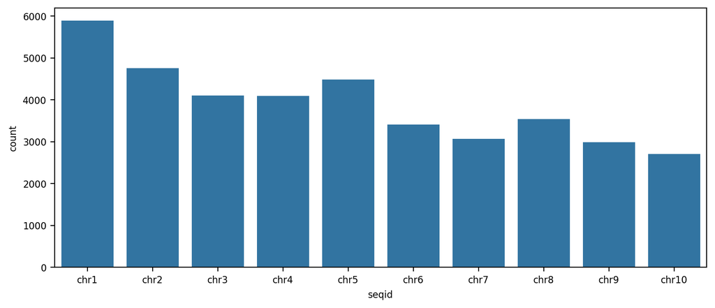

```python
filter = chr_gff3_df['type'] == 'gene'
sns.countplot(data=chr_gff3_df[filter], x='seqid');
```

For `mRNA` features:

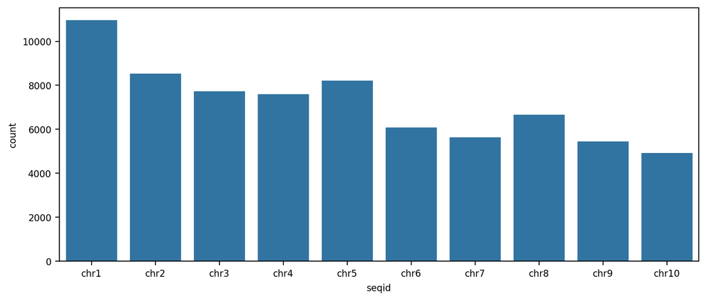

```python
filter = chr_gff3_df['type'] == 'mRNA'
sns.countplot(data=chr_gff3_df[filter], x='seqid');
```

We can also generate histograms to visualize the distribution of feature lengths. Let's view the `CDS` feature length distribution.

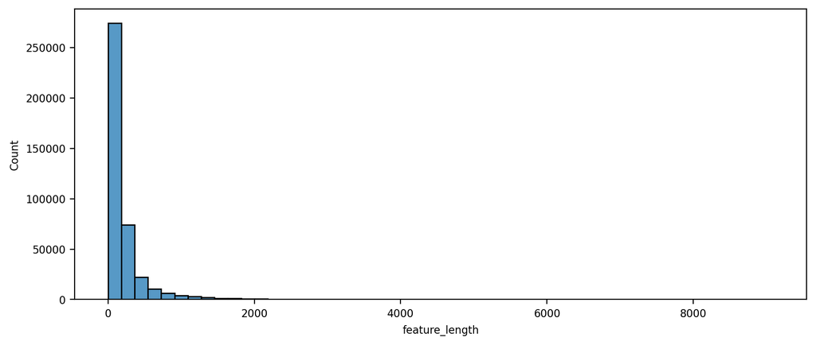

```python
filter = chr_gff3_df['type'] == 'CDS'
sns.histplot(data=chr_gff3_df[filter], x='feature_length', bins=50);
```

To make the distribution more interpretable, we can use a log scale on the x-axis.

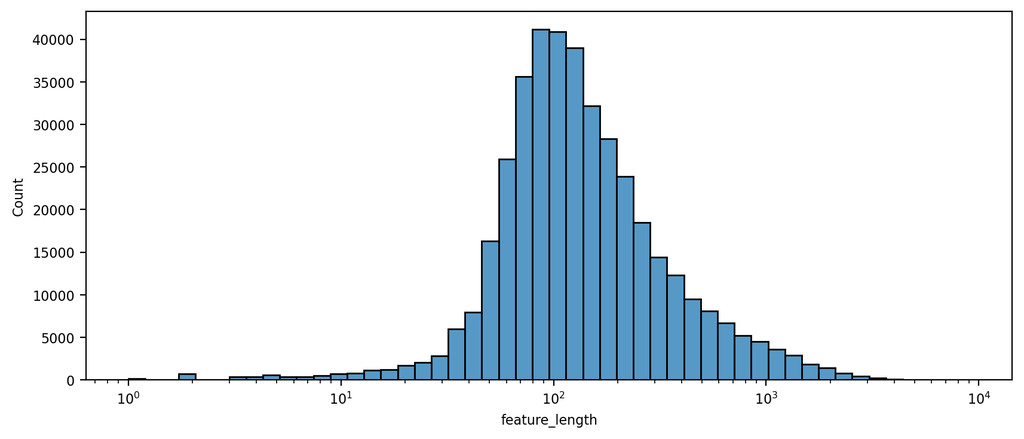

```python
sns.histplot(data=chr_gff3_df[filter], x='feature_length', bins=50, log_scale=True);
```

We can also adjust the bins for more granularity.

[figure not shown]

```python
sns.histplot(data=chr_gff3_df[filter], x='feature_length', bins=200, log_scale=True);
```

We can smooth this using a kernel density estimate plot.

[figure not shown]

```python
sns.histplot(data=chr_gff3_df[filter], x='feature_length', bins=200, kde=True, log_scale=True);
```

We can generate histograms for other features just as easily. For `gene` features:

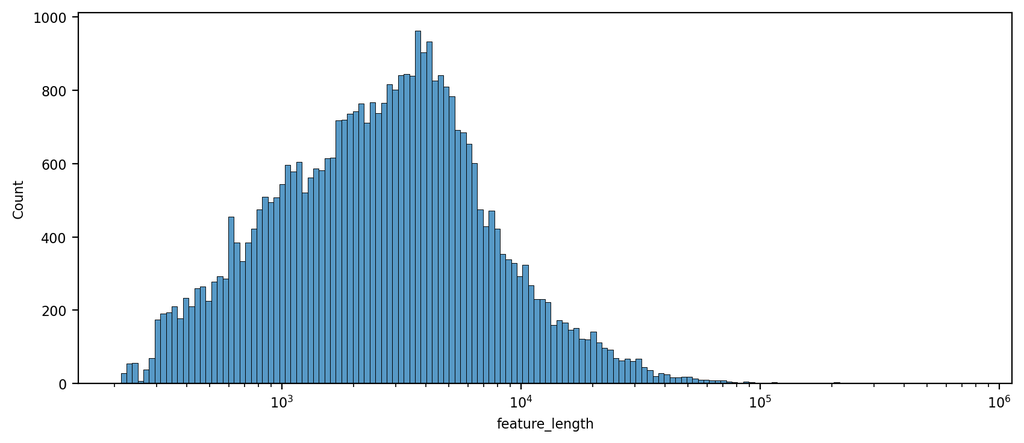

```python
filter = chr_gff3_df['type'] == 'gene'
sns.histplot(data=chr_gff3_df[filter], x='feature_length', bins=150, log_scale=True);
```

To save plots, you can either use the `%%` magic command in Jupyter notebook or use the `savefig` method.

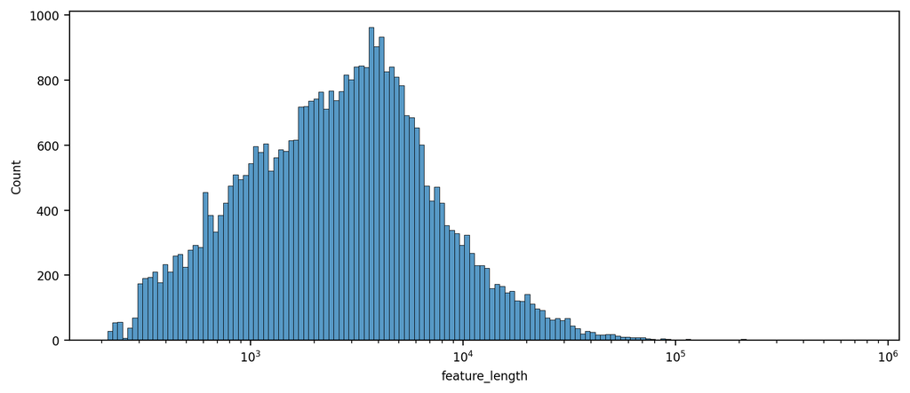

```python
%%capture --no-display fig.png
sns.histplot(data=chr_gff3_df[filter], x='feature_length', bins=150, log_scale=True);
```

or

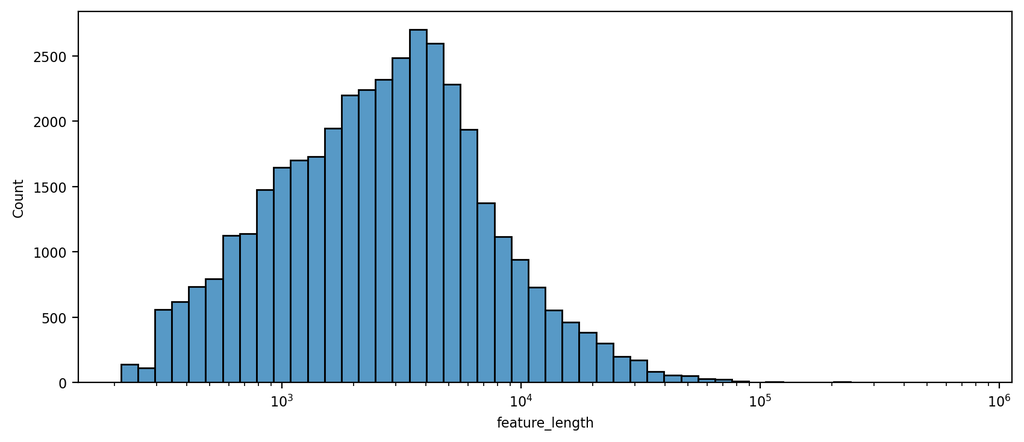

```python
sns.histplot(data=chr_gff3_df[filter], x='feature_length', bins=50, log_scale=True)
plt.savefig('gene_feature_length_distribution.png');
```

This is just a brief introduction to visualization -- we will discuss Seaborn more next time.

## 6. Advanced filtering

Suppose you want to subset your GFF3 file to retain only primary transcripts. You can use the `attributes` column to filter the dataframe. First, let's look at the column:

```python
!head Zm-B73-REFERENCE-NAM-5.0_Zm00001eb.1.gff3 | cut -f9
```

```
##gff-version 3
# generated on Thu Jul  2 15:00:44 2020 by /sonas-hs/ware/hpc/home/olson/src/warelab/gramene-ensembl/scripts/dump-scripts/sharon_gff_dump_by_logicname_nam.pl
# for species Maize b73
# genebuild 2019-cshl
ID=1;Name=chromosome:Zm-B73-REFERENCE-NAM-5.0:1:1:308452471:1
ID=Zm00001eb000010;biotype=protein_coding;logic_name=cshl_gene
ID=Zm00001eb000010_T001;Parent=Zm00001eb000010;biotype=protein_coding;transcript_id=Zm00001eb000010_T001;canonical_transcript=1
Parent=Zm00001eb000010_T001
Parent=Zm00001eb000010_T001;Name=Zm00001eb000010_T001.exon.1;ensembl_end_phase=0;ensembl_phase=0;exon_id=Zm00001eb000010_T001.exon.1;rank=1
Parent=Zm00001eb000010_T001;Name=Zm00001eb000010_T001.exon.2;ensembl_end_phase=0;ensembl_phase=0;exon_id=Zm00001eb000010_T001.exon.2;rank=2
```

Here, we can see that there is an attribute `canonical transcript=1`. In this file, it designates primary transcripts (note: not all gff3 will have it designated this way -- and some will be downright cryptic). But since this gff kindly has that attribute, we can use it to find only primary transcripts.

```python
filter = chr_gff3_df['attributes'].str.contains('canonical_transcript')
chr_gff3_df[filter].head()
```

|  | seqid | source | type | start | end | score | strand | phase | attributes | feature_length |
| --- | --- | --- | --- | --- | --- | --- | --- | --- | --- | --- |
| 2 | chr1 | NAM | mRNA | 34617 | 40204 | . | + | . | ID=Zm00001eb000010_T001;Parent=Zm00001eb000010... | 5588 |
| 85 | chr1 | NAM | mRNA | 41214 | 46762 | . | - | . | ID=Zm00001eb000020_T001;Parent=Zm00001eb000020... | 5549 |
| 107 | chr1 | NAM | mRNA | 108554 | 114382 | . | - | . | ID=Zm00001eb000050_T001;Parent=Zm00001eb000050... | 5829 |
| 124 | chr1 | NAM | mRNA | 188559 | 189581 | . | - | . | ID=Zm00001eb000060_T001;Parent=Zm00001eb000060... | 1023 |
| 132 | chr1 | NAM | mRNA | 190192 | 198832 | . | - | . | ID=Zm00001eb000070_T001;Parent=Zm00001eb000070... | 8641 |

As you see, this will only fetch you `mRNA` features but not its child features like `CDS` or `exon`. If you want to fetch all the child features of the primary transcript, you can use the `mRNA_id` column to filter the dataframe. This command will be more complicated than we have seen before, but let's build it together! We will use:

`mRNA_id = chr_gff3_df[filter]['attributes'].str.split(';', expand=True)[0].str.split('=', expand=True)[1]`

What on earth does this say? Well, we are using the filter we constructed above to retain only rows that contain `canonical_transcript` and then we will access the `attributes` column from those results. From there, we split the attributes string by a `;` and use `expand=True` to make a dataframe where eas column is one key-value pair. From there we use `[0]` to select the first element, which would be something like `ID=Zm00001eb254930_T001`. We again split that string by the `=` and expand it, selecting the second part (right half) to display. Let's see how it works.

```python
# original lines had format like this
# ID=Zm00001eb254920_T001;Parent=Zm00001eb254920;biotype=protein_coding;transcript_id=Zm00001eb254920_T001;canonical...
mRNA_id = chr_gff3_df[filter]['attributes'].str.split(';', expand=True)[0].str.split('=', expand=True)[1]
mRNA_id.head()
```

```
2      Zm00001eb000010_T001
85     Zm00001eb000020_T001
107    Zm00001eb000050_T001
124    Zm00001eb000060_T001
132    Zm00001eb000070_T001
Name: 1, dtype: object
```

This list of ids are the primary transcripts. You can use this list to filter the dataframe just as we have been doing all along `chr_gff3_df[filter]`

We might want to use regular expressions to capture parts of our data. In that case, we can use the module `re` (**r**egular **e**xpressions), which gives us the ability to build our regex using `re.compile`. BUT, it is important to remember that some characters in our data might also be interpreted as regex characters. In this case, we need to use `re.escape`.

```python
import re

# create a pattern to search for the IDs; here we are joining all mRNA_ids
pattern = re.compile('|'.join(mRNA_id))

# Define a function to check if a given attribute contains any of the IDs
def contains_id(attribute):
    return bool(pattern.search(attribute))

# Apply the function to each row in the DataFrame
primary_gff3_df = chr_gff3_df[chr_gff3_df['attributes'].apply(contains_id)]

# Now our dataframe will contain only attributes that contain our mRNA_ids
```

## 7. Iterating over the dataframe

If you want to iterate over the dataframe, you can use the `iterrows` method. This is useful when you want to perform an operation by row (similar to rowwise). Here we will use only the first 250 rows as an example.

```python
chr_gff3_test = chr_gff3_df.head(250)
```

Let's try an iteration function. Here, we will iterate over each lines in our test gff3, selecting only "mRNA" entries, and then we will print columns from that result in the format `chr:start-end`.

```python
for index, row in chr_gff3_test.iterrows():
    if row['type'] == 'mRNA':
        position = f"{row['seqid']}:{row['start']}-{row['end']}"
        print(position)
```

```
chr1:34617-40204
chr1:41263-46050
chr1:41214-43902
chr1:41314-46039
chr1:41214-46762
chr1:108554-114382
chr1:188559-189581
chr1:190192-198832
chr1:200262-203393
chr1:206619-209723
chr1:246422-247242
chr1:315219-315846
chr1:325307-326897
chr1:328087-328525
chr1:550834-564766
chr1:551305-564761
```

Our `for...iterrows()` made a tuple out of every (index, row) in the test gff3. For each of those tuples, if the `row['type']` field was `mRNA`, it saved a temporary object `position` that used the print format `f"{row['seqid']}:{row['start']}-{row['end']}"` and then printed it to the screen. We can do the same thing for "gene", and print the output in a different format:

```python
for index, row in chr_gff3_test.iterrows():
    if row['type'] == 'gene':
        print(row['seqid'], row['type'], row['start'], row['end'])
```

```
chr1 gene 34617 40204
chr1 gene 41214 46762
chr1 gene 108554 114382
chr1 gene 188559 189581
chr1 gene 190192 198832
chr1 gene 200262 203393
chr1 gene 206619 209723
chr1 gene 246422 247242
chr1 gene 315219 315846
chr1 gene 325307 326897
chr1 gene 328087 328525
chr1 gene 550834 564766
```

You can revisit our earlier filtering commands to see if they would be improved by using `iterrows` method. For example, let's get primary transcripts a different way. Earlier we used

`mRNA_id = chr_gff3_df[filter]['attributes'].str.split(';', expand=True)[0].str.split('=', expand=True)[1]` to get a list of mRNA_ids. We can also do it using `iterrows()`.

```python
for index, row in chr_gff3_test.iterrows():
    if 'canonical_transcript' in row['attributes']:
        mRNAid = row['attributes'].split(';')[0].split('=')[1]
        print(mRNAid)
```

```
Zm00001eb000010_T001
Zm00001eb000020_T001
Zm00001eb000050_T001
Zm00001eb000060_T001
Zm00001eb000070_T001
Zm00001eb000080_T001
Zm00001eb000100_T001
Zm00001eb000110_T001
Zm00001eb000120_T001
Zm00001eb000140_T001
Zm00001eb000150_T001
Zm00001eb000170_T004
```

## Conclusion

In this short exercise, we learned how to read a GFF3 file using `pandas`, filter the data, convert the format, calculate summary statistics, and visualize the data. These are some of the common tasks you might encounter while working with GFF3 files.

`pandas` makes working with non-standardized file formats like GFF3 easy and efficient. It provides a powerful set of tools to manipulate and analyze the data.